### Census and Spending

**Nursing Home Census and Spending, by Fiscal Year**

New York State (Since Apr 2011)

| Fiscal Year | Weeks Reported | Census Average Census | Census Annual Change | Census Annual Change % | Census End of Period Census | Gross Spending Medicaid Fee-for-Service Spending | Gross Spending Annual Change | Gross Spending Annual Change % | Average Annual Gross Spending per Capita Medicaid Fee-for-Service Spending | Average Annual Gross Spending per Capita Annual Change | Average Annual Gross Spending per Capita Annual Change % |
| --- | --- | --- | --- | --- | --- | --- | --- | --- | --- | --- | --- |
| FY27 | 16 | 92,104 | 8,820 | 10.59% | 64,580 | NA | NA | NA | NA | NA | NA |
| FY26 | 52 | 83,284 | −7,266 | −8.02% | 96,609 | NA | NA | NA | NA | NA | NA |
| FY25 | 52 | 90,550 | 6,052 | 7.16% | 88,612 | $7,456,000,000 | $606,000,000 | 8.85% | $82,341 | $1,274 | 1.57% |
| FY24 | 52 | 84,498 | 791 | 0.94% | 84,980 | $6,850,000,000 | $440,000,000 | 6.86% | $81,067 | $4,491 | 5.86% |
| FY23 | 52 | 83,707 | 2,000 | 2.45% | 86,392 | $6,410,000,000 | $376,000,000 | 6.23% | $76,577 | $2,727 | 3.69% |
| FY22 | 52 | 81,707 | 3,898 | 5.01% | 84,138 | $6,034,000,000 | $876,000,000 | 16.98% | $73,849 | $7,559 | 11.40% |
| FY21 | 53 | 77,809 | −4,569 | −5.55% | 77,159 | $5,158,000,000 | −$80,000,000 | −1.53% | $66,290 | $2,705 | 4.25% |
| FY20 | 52 | 82,378 | 2,052 | 2.56% | 88,648 | $5,238,000,000 | −$126,000,000 | −2.35% | $63,585 | −$3,193 | −4.78% |
| FY19 | 52 | 80,325 | 2,682 | 3.45% | 83,763 | $5,364,000,000 | −$156,000,000 | −2.83% | $66,778 | −$4,316 | −6.07% |
| FY18 | 52 | 77,644 | 4,044 | 5.49% | 83,558 | $5,520,000,000 | −$580,000,000 | −9.51% | $71,094 | −$11,787 | −14.22% |
| FY17 | 52 | 73,600 | 3,488 | 4.97% | 78,635 | $6,100,000,000 | −$658,000,000 | −9.74% | $82,881 | −$13,508 | −14.01% |
| FY16 | 53 | 70,112 | −6,505 | −8.49% | 77,174 | $6,758,000,000 | $126,000,000 | 1.90% | $96,388 | $9,828 | 11.35% |
| FY15 | 52 | 76,618 | −2,360 | −2.99% | 72,592 | $6,632,000,000 | −$110,000,000 | −1.63% | $86,560 | $1,194 | 1.40% |
| FY14 | 52 | 78,978 | −4,793 | −5.72% | 85,829 | $6,742,000,000 | −$92,000,000 | −1.35% | $85,366 | $3,786 | 4.64% |
| FY13 | 52 | 83,770 | −3,309 | −3.80% | 48,527 | $6,834,000,000 | $745,114,000 | 12.24% | $81,580 | $11,656 | 16.67% |
| FY12 | 52 | 87,079 | NA | NA | 93,333 | $6,088,886,000 | NA | NA | $69,924 | NA | NA |

**Data Sources:** Health Data NY; NYSDOH Global Spending Cap Reports  
**Data as of:** July 31, 2026

**Data Sources:** [Health Data NY](https://health.data.ny.gov/Health/Nursing-Home-Weekly-Bed-Census-Beginning-2009/uhyy-xp9s/about_data); [New York State Department of Health](https://www.health.ny.gov/health_care/medicaid/regulations/global_cap/)

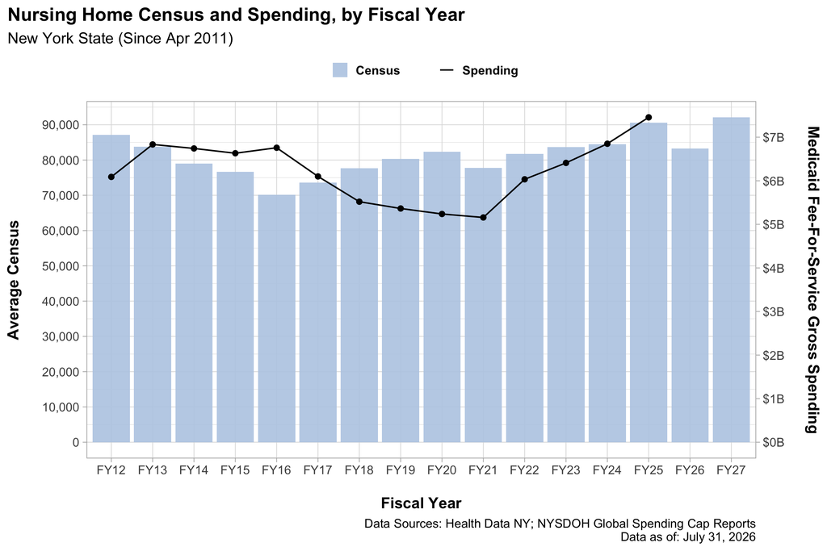

**Data Sources:** [Health Data NY](https://health.data.ny.gov/Health/Nursing-Home-Weekly-Bed-Census-Beginning-2009/uhyy-xp9s/about_data); [New York State Department of Health](https://www.health.ny.gov/health_care/medicaid/regulations/global_cap/)

### Census, Trends Over Time

**Nursing Home, Annual Average Census**

New York State (Since Apr 2009)

| Year | Mean Census | Increase/Decrease | % Increase/Decrease |
| --- | --- | --- | --- |
| 2026 | 88,691 | 4,515 | 5.36% |
| 2025 | 84,176 | −7,547 | −8.23% |
| 2024 | 91,723 | 9,096 | 11.01% |
| 2023 | 82,627 | −507 | −0.61% |
| 2022 | 83,134 | 2,554 | 3.17% |
| 2021 | 80,580 | 816 | 1.02% |
| 2020 | 79,764 | −1,666 | −2.05% |
| 2019 | 81,430 | 1,690 | 2.12% |
| 2018 | 79,740 | 3,004 | 3.91% |
| 2017 | 76,737 | 3,756 | 5.15% |
| 2016 | 72,980 | 3,044 | 4.35% |
| 2015 | 69,937 | −8,413 | −10.74% |
| 2014 | 78,350 | −387 | −0.49% |
| 2013 | 78,737 | −6,008 | −7.09% |
| 2012 | 84,744 | −2,274 | −2.61% |
| 2011 | 87,018 | −7,243 | −7.68% |
| 2010 | 94,261 | −5,518 | −5.53% |
| 2009 | 99,780 | NA | NA |

**Data Source:** Health Data NY  
**Data as of:** July 31, 2026

**Data Source:** [Health Data NY](https://health.data.ny.gov/Health/Nursing-Home-Weekly-Bed-Census-Beginning-2009/uhyy-xp9s/about_data)

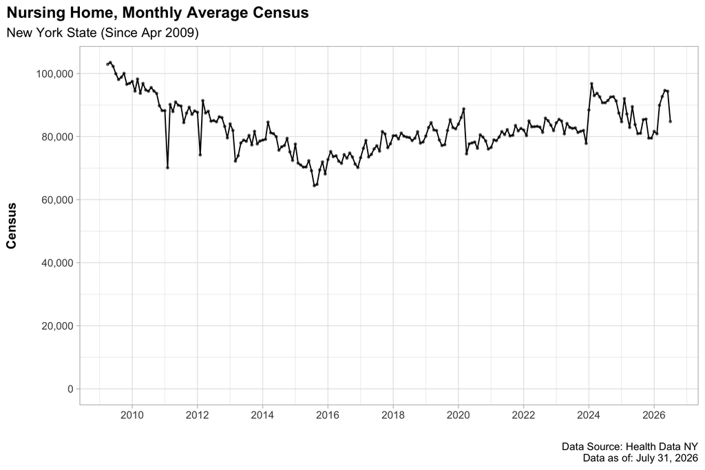

**Data Source:** [Health Data NY](https://health.data.ny.gov/Health/Nursing-Home-Weekly-Bed-Census-Beginning-2009/uhyy-xp9s/about_data)

### Technical Notes

1. Data include nursing home beds, pediatric beds, behavioral intervention beds, ventilator beds, scatter ventilator beds, traumatic brain injury beds, neurodegenerative disease beds; exclude pediatric ventilator beds, dialysis station beds, and adult day health care slots.
2. Spending data represent Medicaid fee-for-service spending only. Spending may include other minor related categories of service spending, such as adult day health care.
3. Gross spending is estimated assuming a [50% federal match](https://www.kff.org/medicaid/state-indicator/federal-matching-rate-and-multiplier/?currentTimeframe=0&sortModel=%7B%22colId%22:%22Location%22,%22sort%22:%22asc%22%7D) to the State spending reported in quarterly Global Cap Reports.
4. Census data represent all occupied beds, regardless of payor type.
5. *Beds* = The number of Residential Beds the facility is approved to operate.
6. *Beds Available* = Available Residential Beds reported by facility. This figure should include any licensed beds that are not operational.
7. *Census (aka “Occupied Beds”)* = (Beds) - (Beds Available).
8. *End of Period Census* The total number of occupied beds at the end of the reporting period. For completed fiscal years, this represents the census at the end of the year. For partial fiscal years, it reflects the census as of the most recent reporting date.